# Climbs

2019-05-04

The data comes from [2019 Giro road book](http://www.giroditalia.it/wp-content/uploads/2019/04/Garibaldi_Giro_italia_2019_low_res.pdf) and has been downloaded using the tabulizer package `tabulizer::extract_tables("http://www.giroditalia.it/wp-content/uploads/2019/04/Garibaldi_Giro_italia_2019_low_res.pdf", pages = c(17, 18))`.

The following report is an analysis of Giro 2019 categorized climbs. It contains:

1. a detailed overview of each climb,
2. an overview of climbs by stages,
3. total elevation gained by stages and
4. an overview sorted by elevation gained.

You can download the whole package including the data and all the reports with `devtools::install_github("schubertjan/giro2019")`.

## 1. Overview of each classified climbs

Below is a detailed overview of all classified climbs in chronological order. The x axis shows the length of a climb (km), the y axis elevation difference (m). All charts use the same axis to allow relative comparison. The colour represents climb’s category.

- Black = cat 1
- Red = cat 2
- Orange = cat 3
- Green = cat 4

```r
library(giro2019)
library(DT)

DT::datatable(climbs[, c(1,4,5,11,12,13)], rownames = FALSE)
```

| tappa | gpm | cat | lungh.(km) | disl.(m) | p.med |
| --- | --- | --- | --- | --- | --- |
| 1 | SANLUCA | 3 | 2.1 | 204 | 9.7 |
| 2 | Montalbano(ilCastra) | 3 | 5.8 | 395 | 6.8 |
| 2 | SanBaronto | 4 | 11.3 | 273 | 2.4 |
| 3 | Poggiol'Apparita | 4 | 3.8 | 185 | 4.9 |
| 4 | Manciano | 4 | 8 | 297 | 3.7 |
| 5 | Sezze | 4 | 3.9 | 201 | 5.2 |
| 6 | CoppaCasarinelle | 2 | 15 | 655 | 4.4 |
| 7 | LeSvoltediPopoli | 2 | 8.9 | 497 | 5.6 |
| 8 | MontedellaMattera | 3 | 9.1 | 352 | 3.9 |
| 8 | Monteluro | 4 | 6 | 180 | 3 |

[output cut: 29 more lines]

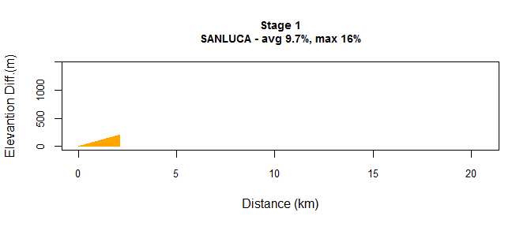

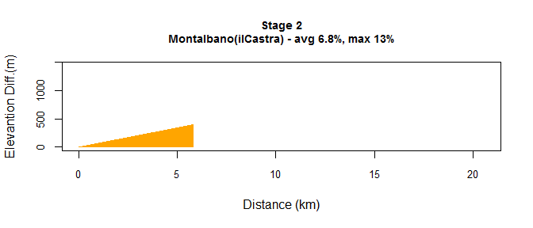

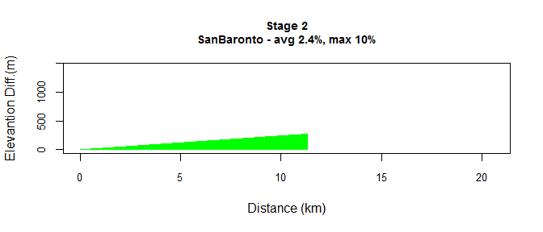

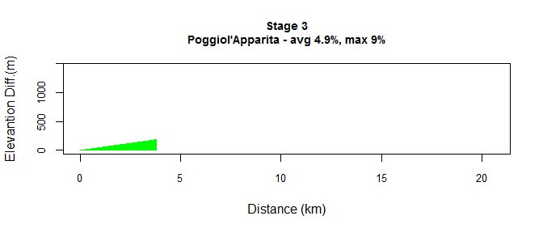

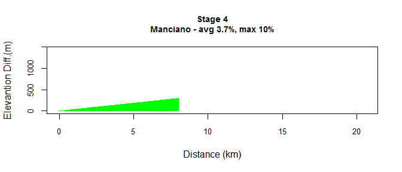

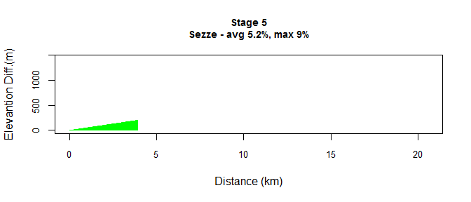

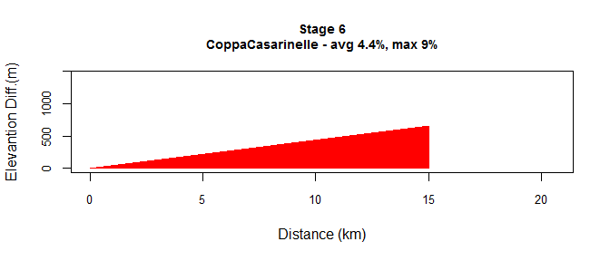

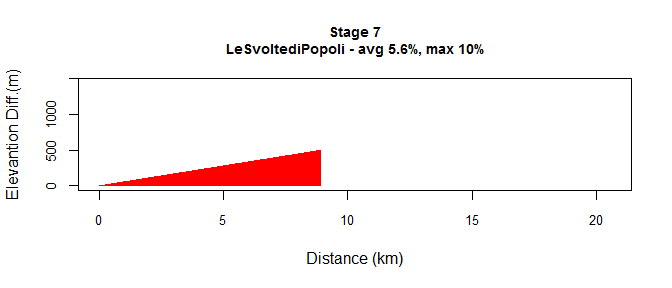

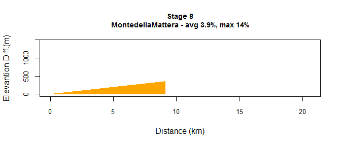

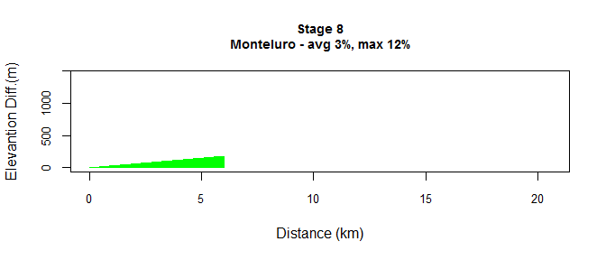

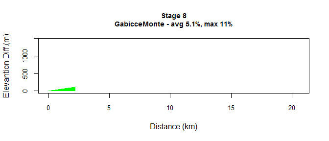

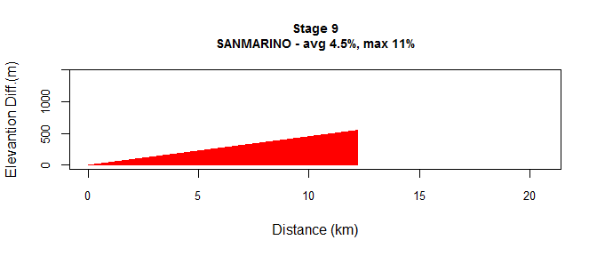

[27 more figures not shown]

```r
x <- lapply(1:nrow(climbs), function(i) {
  dat <- giro2019::createhilldata(x = climbs$`lungh.(km)`[i],
                                  y = climbs$`disl.(m)`[i],
                                  cat = climbs$cat[i])
  giro2019::hillplot(x = dat$x,
                     y = dat$y,
                     col_plot = dat$plot_col,
                     x_lim = max(climbs$`lungh.(km)`),
                     y_lim = max(climbs$`disl.(m)`),
                     stage = climbs$tappa[i],
                     climb_name = climbs$gpm[i],
                     avg_p = climbs$p.med[i],
                     max_p = climbs$p.max[i])
})
```

## 2. Overview of all classified climbs by stages

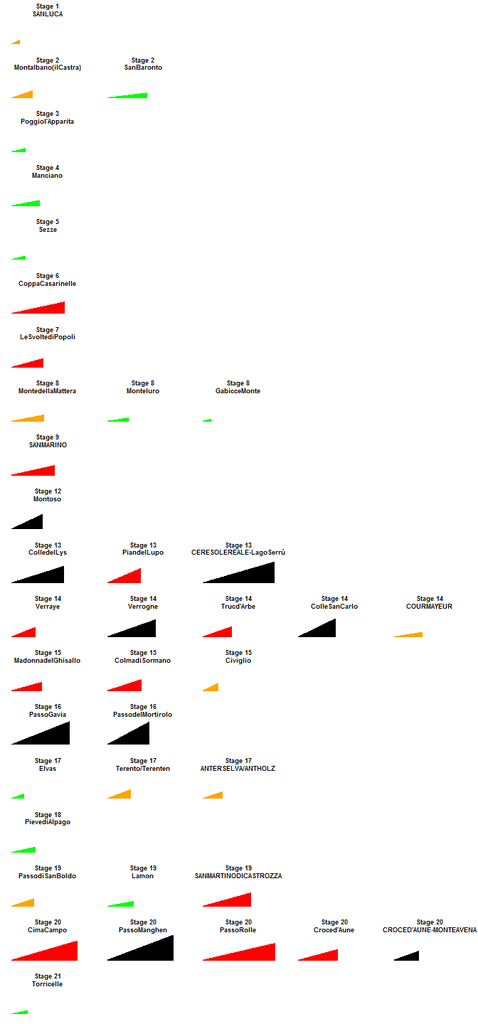

```r
#pre-process data
climbs_l <- split(climbs,climbs$tappa)
n <- lapply(climbs_l,function(x) nrow(x) + 1)
#creare NA for stages with  < 5 climbs
for(i in 1:length(climbs_l)){
  if(n[i] != 6){
    for(j in n[[i]]:5){
      climbs_l[[i]][j, ] <- NA
      }
  }
}
climbs_full <- do.call(rbind, climbs_l)


par(mfrow = c(19,5), mar = c(1,1,2,1))
x <- lapply(1:nrow(climbs_full), function(i) {
  #create data
  x <- c(0, climbs_full$`lungh.(km)`[i])
  y <- c(0, climbs_full$`disl.(m)`[i])
  #if no data plot empty else plot climb
  if(is.na(x[2])) {
      plot(0,0,type = "n", axes = FALSE,ann = FALSE)
  } else {
  dat <- giro2019::createhilldata(x = climbs_full$`lungh.(km)`[i],
                                  y = climbs_full$`disl.(m)`[i],
                                  cat = climbs_full$cat[i])
  giro2019::hillplot(x = dat$x,
                     y = dat$y,
                     col_plot = dat$plot_col,
                     x_lim = max(climbs_full$`lungh.(km)`, na.rm = TRUE),
                     y_lim = max(climbs_full$`disl.(m)`, na.rm = TRUE),
                     stage = climbs_full$tappa[i],
                     climb_name = climbs_full$gpm[i],
                     showaxis = FALSE)
  }
})
```

## 3. Elevation gained from categorized climbs by stages

This chart shows total elevation gained in categorized climbs. Vertical lines show rest days. Stage 20 is brutal; more than 4600m of categorized climbing!

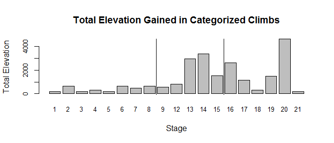

```r
elev_stage <- aggregate(`disl.(m)` ~ tappa,
                        data = climbs,
                        FUN = sum)
barplot(height = elev_stage$`disl.(m)`,
        names.arg = elev_stage$tappa,
        xlab = "Stage",
        ylab = "Total Elevation",
        main = "Total Elevation Gained in Categorized Climbs",
        cex.axis = .8,
        cex.names = .8)
abline(v = 9.7)
abline(v = 15.7)
```

```r
DT::datatable(elev_stage,
              rownames = FALSE,
              options = list(pageLength = 10))
```

| tappa | disl.(m) |
| --- | --- |
| 1 | 204 |
| 2 | 668 |
| 3 | 185 |
| 4 | 297 |
| 5 | 201 |
| 6 | 655 |
| 7 | 497 |
| 8 | 645 |
| 9 | 549 |
| 12 | 838 |

[output cut: 9 more lines]

## 4. Overview of all classified climbs sorted by elevation difference

No surprise here, a few climbs look pretty steep for cat 4 :)

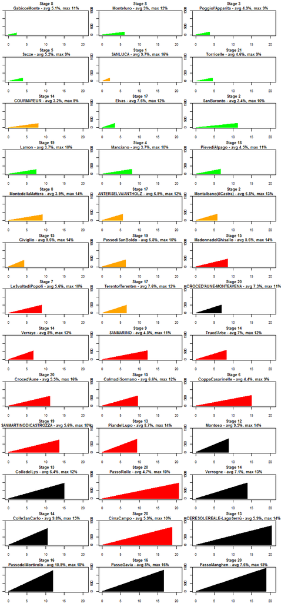

```r
climbs <- climbs[order(climbs$`disl.(m)`), ]

par(mfrow = c(13,3), mar = c(2,1,2,1))
x <- lapply(1:nrow(climbs), function(i) {
    dat <- giro2019::createhilldata(x = climbs$`lungh.(km)`[i],
                                    y = climbs$`disl.(m)`[i],
                                    cat = climbs$cat[i])
    giro2019::hillplot(x = dat$x,
                       y = dat$y,
                       col_plot = dat$plot_col,
                       x_lim = max(climbs$`lungh.(km)`),
                       y_lim = max(climbs$`disl.(m)`),
                       stage = climbs$tappa[i],
                       climb_name = climbs$gpm[i],
                       avg_p = climbs$p.med[i],
                       max_p = climbs$p.max[i],
                       showaxis = TRUE)
})
```